# Feem Data Analysis

Sumit

2023-06-23

# FEEM data Analysis

Fluoroscence Excitation Emission Matrix. It is a two-dimensional data format that represents a sample’s fluorescence properties at various excitation and emission wavelengths.

##### FEEM data analysis requires many steps:

1. Importing and correcting file names: This step involve importing the raw file and correcting its fataframe name corresponding to its value, because while exporting the file from Horiba aqualog to .opj file it randomly distributes its dataframe.
2. Check Data: In this step we check the structure of raw data, and weather the main dataframes are available or not which are S1/R1 , S1c/R1c file, Absorbance Blank, Absorbance Sample and Sample-Blank. Later we will know what fd contain which data.
3. Inner Filter Effect: The inner filter effect describes the attenuation of excitation and/or emission light caused by the presence of absorbing or scattering components in the sample. To get proper fluorescence intensities, we need to evaluate and compensate for this effect.
4. Scattering removal : Removing of scattering band caused by 1st and 2nd order of Raman and Rayleigh Scattering. **Raman scattering** is an inelastic scattering phenomena in which light interacts with molecules, resulting in a frequency shift of the scattered light. It offers information on molecular vibrational and rotational states, allowing for chemical identification and study. **Rayleigh scattering**, on the other hand, is an elastic scattering of light caused by particles or molecules far smaller than the wavelength of the incident light. It is responsible for the blue colour of the sky and does not involve a frequency shift.
5. Normalization

##### Importing libraries thet will be needed, if not installed then install it first.

```r
library(eemR)
library(Ropj)
library("tidyverse")
```

Here data is the raw data file and S1 is the Sample 1 in the Raw data.

```r
data <- read.opj('/Users/sumitkumargupta/Desktop/Dal /FEEM/Raw Data.opj')
S1 <- data$BSC1041
summary(S1)
```

```
##                               Length Class      Mode
## Note                          189    data.frame list
## Abs Spectrum Blank            189    data.frame list
## S1 Blank                       20    data.frame list
## S1 Dark and Mcorrect Blank      5    data.frame list
## S1c Blank                       9    data.frame list
## R1 and R1c Blank                3    data.frame list
## S1c/R1c Blank                 189    data.frame list
## Abs Spectrum Sample            20    data.frame list
## S1 Sample                     189    data.frame list
## S1 Dark and Mcorrect Sample    20    data.frame list
## S1c Sample                      3    data.frame list
## R1 and R1c Sample             189    data.frame list
## S1c/R1c Sample                  5    data.frame list
## Sample - Blank                189    data.frame list
## Sample - Blank  XYZ             3    data.frame list
## Abs Spectra Graphs             11    data.frame list
## Waterfall Plot Blank            1    data.frame list
## Waterfall Plot Sample          20    data.frame list
## Sample - Blank Waterfall Plot 189    data.frame list
## Sample - Blank Contour Plot    32    data.frame list
## Processed Graph: IFE           20    data.frame list
## Processed Data: IFE           189    data.frame list
## Processed XYZ: IFE              3    data.frame list
## Processed Contour: IFE         20    data.frame list
```

```r
Current_df_name <- c( "Note", "Abs Spectrum Blank " ,"S1 Blank",                   "S1 Dark and Mcorrect Blank",
"S1c Blank", "R1 and R1c Blank",  "S1c/R1c Blank", "Abs Spectrum Sample",
"S1 Sample",  "S1 Dark and Mcorrect Sample",  "S1c Sample", "R1 and R1c Sample", "S1c/R1c Sample",  "Sample - Blank", "Sample - Blank  XYZ",  "Abs Spectra Graphs",   "Waterfall Plot Blank",   "Waterfall Plot Sample",  "Sample - Blank Waterfall Plot", "Sample - Blank Contour Plot" )

Correct_dataframe_name <- c( "S1 Blank",
"S1c Blank",
"-",
"R1 and R1c Blank",
"Abs Spectrum Blank",
"S1 Dark and Mcorrect Sample",
"Sample - Blank",
"-",
"S1 Blank",
"-",
"S1 Dark and Mcorrect Sample",
"S1c Sample",
"R1 and R1c Sample ",
"S1c/R1c Sample ",
"Sample - Blank  XYZ",
"Abs Spectrum Sample ",
"-",
"-",
"S1c/R1c Blank",
"-"
  )

data.frame(Current_df_name, Correct_dataframe_name)
```

```
##                  Current_df_name      Correct_dataframe_name
## 1                           Note                    S1 Blank
## 2            Abs Spectrum Blank                    S1c Blank
## 3                       S1 Blank                           -
## 4     S1 Dark and Mcorrect Blank            R1 and R1c Blank
## 5                      S1c Blank          Abs Spectrum Blank
## 6               R1 and R1c Blank S1 Dark and Mcorrect Sample
## 7                  S1c/R1c Blank              Sample - Blank
## 8            Abs Spectrum Sample                           -
## 9                      S1 Sample                    S1 Blank
## 10   S1 Dark and Mcorrect Sample                           -
## 11                    S1c Sample S1 Dark and Mcorrect Sample
## 12             R1 and R1c Sample                  S1c Sample
## 13                S1c/R1c Sample          R1 and R1c Sample
## 14                Sample - Blank             S1c/R1c Sample
## 15           Sample - Blank  XYZ         Sample - Blank  XYZ
## 16            Abs Spectra Graphs        Abs Spectrum Sample
## 17          Waterfall Plot Blank                           -
## 18         Waterfall Plot Sample                           -
## 19 Sample - Blank Waterfall Plot               S1c/R1c Blank
## 20   Sample - Blank Contour Plot                           -
```

After importing the data and looking at dataframe and their values, observance was made that it contain data of different dataframes, so here is the correct name . First column contain the dataframe name showm, and second column is the name of dataframe , whose value it actually containing. From here we will refer the correct dataframe name.

# Blank Subtraction

Here we will subtract the corrected blank data from the corrected sample data. Now we will see what the corrected data means, 1. `S1` and `S1 Blank` dataframe contains the raw values, and `S1 Dark and Mcorrect` dataframe containd S1 dark and Mcorrect. The formula to correct this is **S1c = (S1 - S1 Dark) * Mcorrect**, where S1c means S1 corrected, we will do same calculation for Blank file also and then subtract the blank from sample.

Here sample_blank is Sample - Blank

```r
sample_blank <- S1$`Sample - Blank`[ , -1] - S1$`Sample - Blank Waterfall Plot`[ , -1]
```

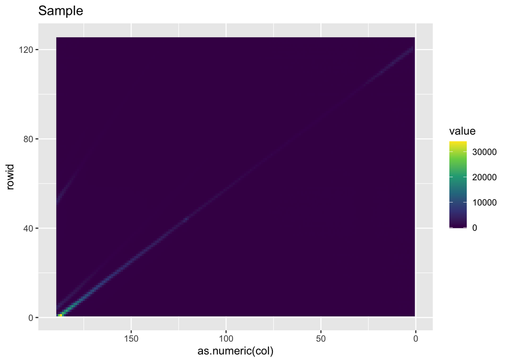

```r
S1$`Sample - Blank` %>%
  data.frame() %>%
  setNames(1:189) %>%
  rowid_to_column() %>%
  pivot_longer(-rowid, names_to = "col") %>%
  ggplot(aes(as.numeric(col), rowid, fill = value)) +
  scale_fill_viridis_c() +
  geom_raster() +
  labs(title = "Sample") +
  scale_x_reverse()
```

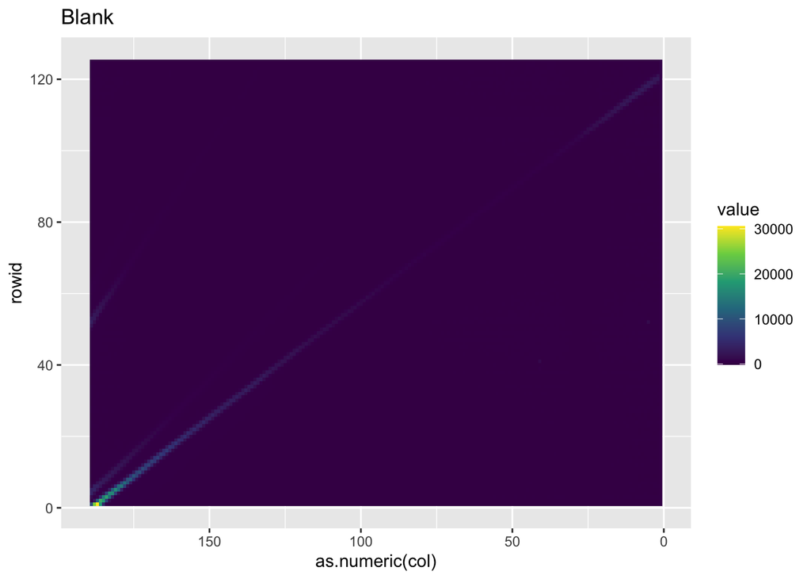

```r
S1$`Sample - Blank Waterfall Plot` %>%
  data.frame() %>%
  setNames(1:189) %>%
  rowid_to_column() %>%
  pivot_longer(-rowid, names_to = "col") %>%
  ggplot(aes(as.numeric(col), rowid, fill = value)) +
  scale_fill_viridis_c() +
  geom_raster() +
  labs(title = "Blank") +
  scale_x_reverse()
```

```r
identical(sample_blank, S1$`S1c/R1c Blank`[ , -1] )
```

```
## [1] TRUE
```

As we verified that `S1c/R1c Blank` df after subtracting Corrected blank from correct Sample.

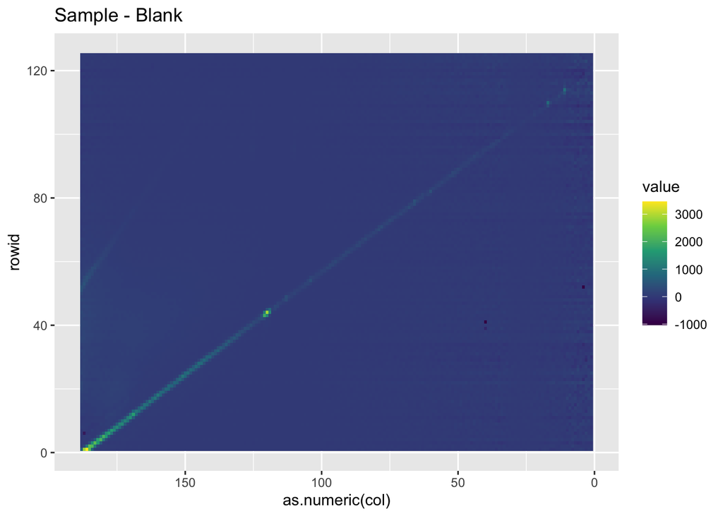

```r
sample_blank %>%
  data.frame() %>%
  setNames(1:188) %>%
  rowid_to_column() %>%
  pivot_longer(-rowid, names_to = "col") %>%
  ggplot(aes(as.numeric(col), rowid, fill = value)) +
  scale_fill_viridis_c() +
  geom_raster() +
  labs(title = "Sample - Blank") +
  scale_x_reverse()
```

# Inner Filter Effect

So for inner filter effect, the formula is **`Fideal = Fobs * 10^(Aex + Aem)0.5`** where Fideal is the ideal fluorescence-signal spectrum expected in the absence of IFE, Fobs is the observed fluorescence signal, and AbsEx and AbsEm are the measured absorbance values at the respective excitation and emission wavelength-coordinates. We only have Aex in dataframe name `Abs Spectrum Sample`, to find the Absorbance value of Emission we have to interpolate, as we have absorbance value of Excitation.

Now we have many methods for interpolation, we will try some of here to find absorbance of emission.

#### Method 1

```r
library(stats)
excitation_absorption <- S1$`Abs Spectra Graphs`$J[1:188]
excitation_wavelength <- S1$`Abs Spectra Graphs`$A[1:188]

# Perform spline interpolation

spline_func <- splinefun(excitation_wavelength,excitation_absorption )

#spline_func <- splinefun(excitation_wavelength, excitation_absorption)

# Generate interpolated absorption values for the emission wavelengths
emission_wavelengths <- S1[["Sample - Blank"]]$A  # Range of emission wavelengths
interpolated_absorption <- spline_func(emission_wavelengths) # interpolated absorbance value
```

Creating df containing Exitation and Absorbance, and Emission and Absorbance corresponding to Emission.

```r
abs_data_ex <- data.frame(wavelength = excitation_wavelength, absorbance = excitation_absorption )
abs_data_em <- data.frame(wavelength = emission_wavelengths, absorbance = interpolated_absorption )
```

Now we have interpolated absorbance value, we will create a matrix with `no. of excitation values` * `no. of emission values` , and corresponding value containd sum of Absorbance.

```r
abs_sum_df <- data.frame(matrix(0, nrow = nrow(abs_data_em), ncol = nrow(abs_data_ex)))

colnames(abs_sum_df) <- abs_data_ex[, 1]
rownames(abs_sum_df) <- abs_data_em[, 1]

for (i in 1:nrow(abs_data_em)) {
  for (j in 1:nrow(abs_data_ex)) {
    # Calculate the sum of absorbance values for the corresponding wavelengths
    abs_sum_df[i, j] <- abs_data_em[i, 2] + abs_data_ex[j, 2]
  }
}
```

We are applying this formula **`Fideal = Fobs * 10^(Aex + Aem)0.5`** , `abs_sum_df` contains `Aex + Aem`.

```r
abs_factor_df <- 10^(abs_sum_df/2)
```

Now to get F ideal we will multiply F obs with correction factor, which is`10^(Aex + Aem)0.5`

```r
data_IFE <- sample_blank*abs_factor_df
```

**data_IFE** Contains Inner Filter Corrected data by Method 1.

#### Method 2 IFE

“fmm”, “periodic”, “natural”, “monoH.FC”, “hyman”, this are the methods available in stats package for interpolation, best fit out of this is from `method = 'monoH.FC'`.

```r
  sf <- stats::splinefun(excitation_wavelength, excitation_absorption, method = 'monoH.FC')

  ex <- sf(abs_data_ex$wavelength)
  em <- sf(abs_data_em$wavelength)

  # Calculate total absorbance in 1 cm cuvette.
  # This also assume that the fluorescence has been measured in 1 cm cuvette.
  total_absorbance <- sapply(ex, function(x) {
    x + em
  })

  max_abs <- max(total_absorbance)

  if (max_abs > 1.5) {
    cat("Total absorbance is > 1.5 (Atotal = ", max_abs, ")\n",
      "A 2-fold dilution is recommended. See ?eem_inner_filter_effect.\n",
      sep = ""
    )
  }

  ife_correction_factor <- 10^(0.5 * total_absorbance)

  cat(
    "Range of IFE correction factors:",
    round(range(ife_correction_factor), digits = 4), "\n"
  )
```

```
## Range of IFE correction factors: 0.9983 1.013
```

```r
corrected_ife <- sample_blank*ife_correction_factor
```

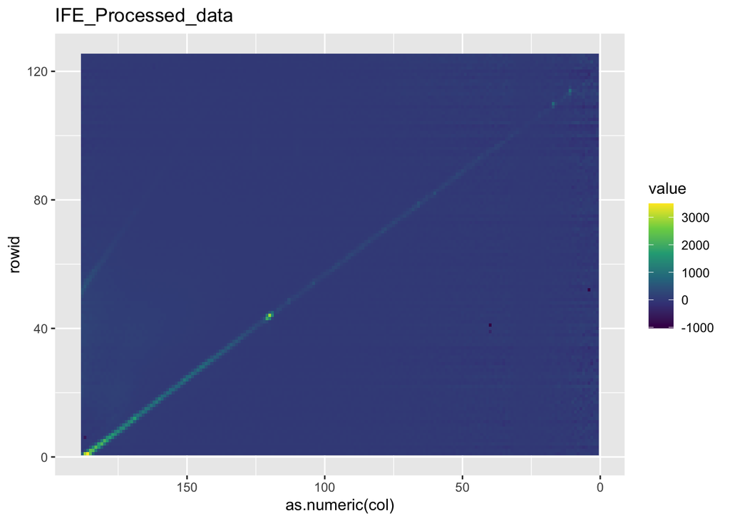

```r
data_IFE %>%
  data.frame() %>%
  setNames(1:188) %>%
  rowid_to_column() %>%
  pivot_longer(-rowid, names_to = "col") %>%
  ggplot(aes(as.numeric(col), rowid, fill = value)) +
  scale_fill_viridis_c() +
  geom_raster() +
  labs(title = "IFE_Processed_data") +
  scale_x_reverse()
```

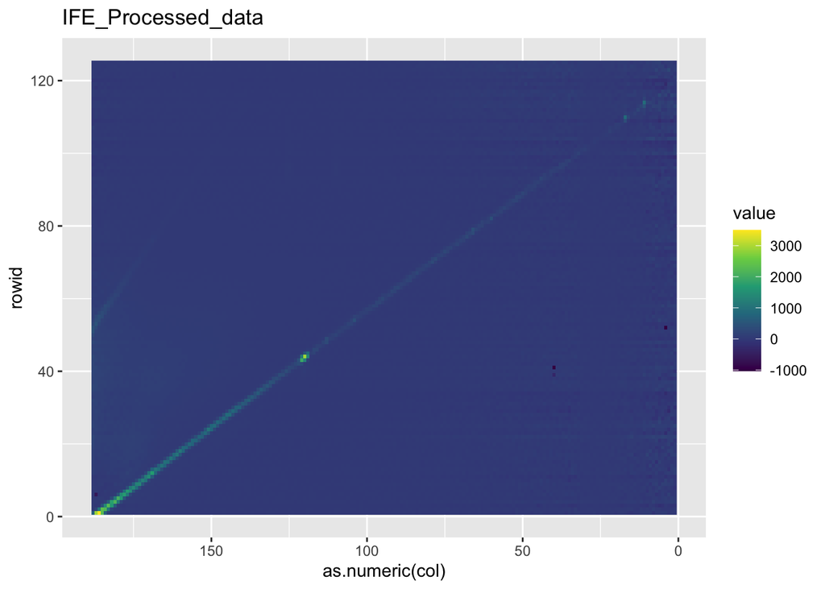

```r
corrected_ife %>%
  data.frame() %>%
  setNames(1:188) %>%
  rowid_to_column() %>%
  pivot_longer(-rowid, names_to = "col") %>%
  ggplot(aes(as.numeric(col), rowid, fill = value)) +
  scale_fill_viridis_c() +
  geom_raster() +
  labs(title = "IFE_Processed_data") +
  scale_x_reverse()
```

# Scattering Correction

```r
ex <- seq(800, length.out = 189, by = -3)
em <- S1$Note$A
```

```r
raman_peak <- (-ex) / ((0.00036 * ex) - 1)
```

```r
ind1 <- outer(em, 1 * ex - 10, "<=")
ind2 <- outer(em, 1 * ex + 10, "<=")
ind3 <- ifelse(ind1 + ind2 == 1, 0, 1)
data_2 <- data_IFE
first_order_corrected <- data_2 * ind3
```

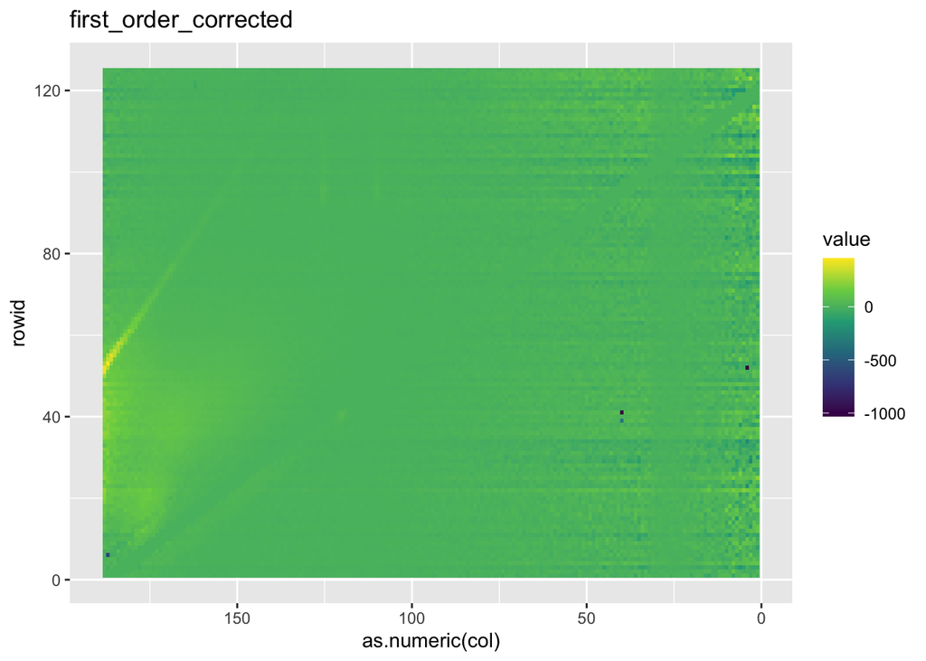

```r
first_order_corrected %>%
  data.frame() %>%
  setNames(1:188) %>%
  rowid_to_column() %>%
  pivot_longer(-rowid, names_to = "col") %>%
  ggplot(aes(as.numeric(col), rowid, fill = value)) +
  scale_fill_viridis_c() +
  geom_raster() +
  labs(title = "first_order_corrected") +
  scale_x_reverse()
```

```r
in_1 <- outer(em, (2 * ex) - 10, "<=")
in_2 <- outer(em, (2 * ex) + 10, "<=")
in_3 <- ifelse(in_1 + in_2 == 1, 0, 1)
second_order_corrected <- first_order_corrected * in_3
```

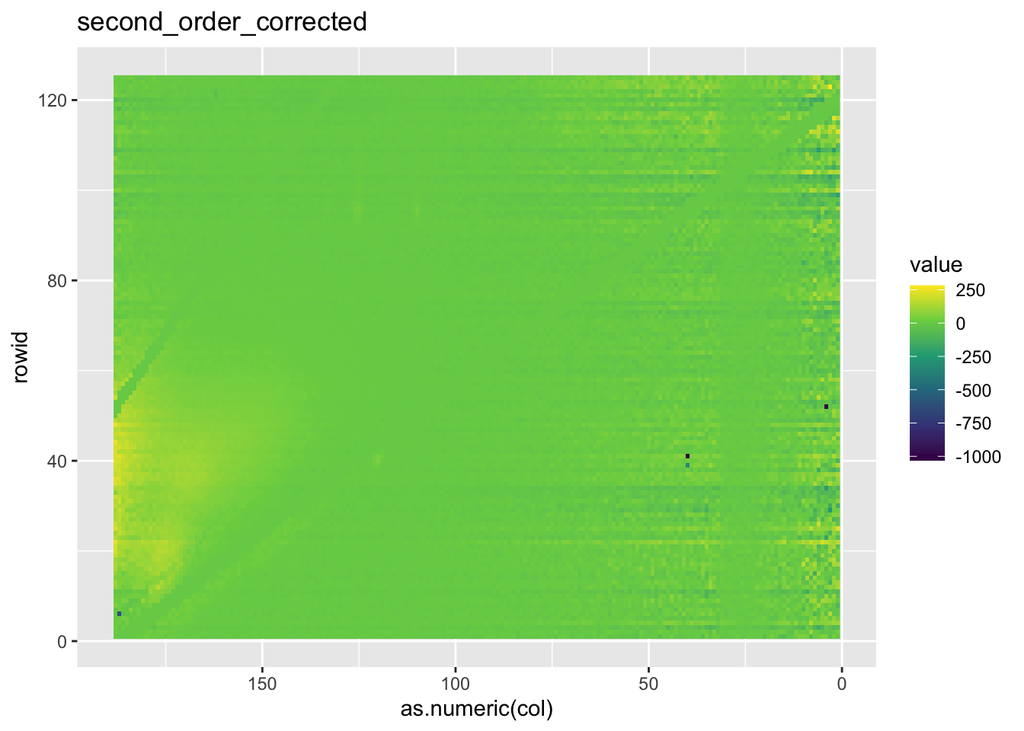

```r
second_order_corrected %>%
  data.frame() %>%
  setNames(1:188) %>%
  rowid_to_column() %>%
  pivot_longer(-rowid, names_to = "col") %>%
  ggplot(aes(as.numeric(col), rowid, fill = value)) +
  scale_fill_viridis_c() +
  geom_raster() +
  labs(title = "second_order_corrected") +
  scale_x_reverse()
```

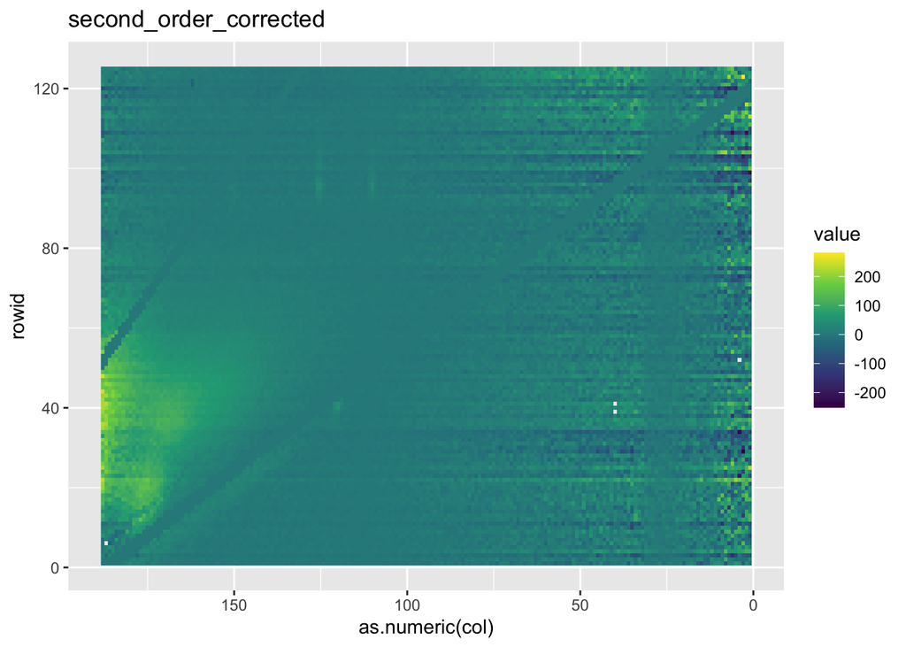

```r
library(dplyr)
library(tidyr)
library(ggplot2)

second_order_corrected %>%
  data.frame() %>%
  setNames(1:188) %>%
  rowid_to_column() %>%
  pivot_longer(-rowid, names_to = "col") %>%
  filter(value >= -300) %>%
  ggplot(aes(as.numeric(col), rowid, fill = value)) +
  scale_fill_viridis_c() +
  geom_raster() +
  labs(title = "second_order_corrected") +
  scale_x_reverse()
```

# Raman Normalisation

Raman normalisation is a technique for adjusting fluorescence readings to account for the effect of Raman scattering. Raman scattering is a process that occurs when incident light interacts with a material and scatters at different wavelengths, resulting in undesired background signals that might interfere with fluorescence measurements.

```r
new_df <- subset(data$blank1$S1c , data$blank1$S1c$B >= 371 & data$blank1$S1c$B <= 428 & data$blank1$S1c$A == 350)
new_df
```

```
##         A       B          C
## 18779 350 373.161  22.319393
## 18780 350 377.748  25.350321
## 18781 350 382.339  16.669420
## 18782 350 386.932  46.727486
## 18783 350 391.529 178.274860
## 18784 350 396.129 360.130368
## 18785 350 400.732 281.059784
## 18786 350 405.338  93.080465
## 18787 350 409.948  21.598552
## 18788 350 414.560  11.796576
## 18789 350 419.176   4.350658
## 18790 350 423.795   4.275462
```

```r
area <- sum((new_df$B[-1] - new_df$B[-length(new_df$B)]) * (new_df$C[-length(new_df)] + new_df$C[-1]) / 2)
area
```

```
## [1] 4812.788
```

```r
corrected_data <- second_order_corrected
final_corrected <- corrected_data/area
```

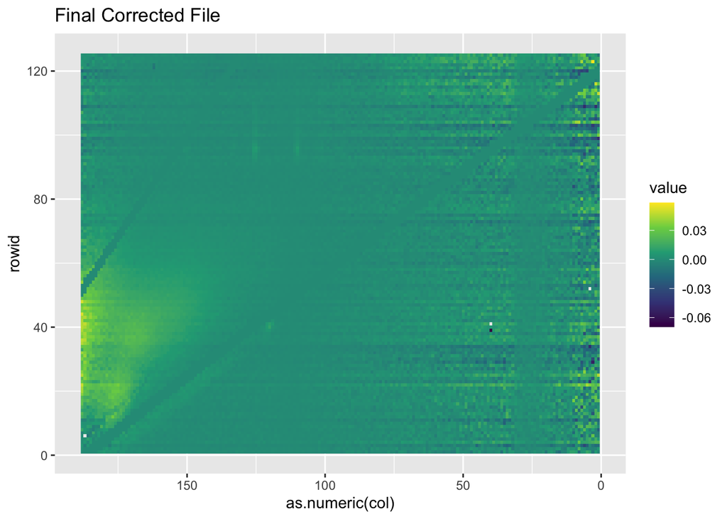

```r
final_corrected %>%
  data.frame() %>%
  setNames(1:188) %>%
  rowid_to_column() %>%
  pivot_longer(-rowid, names_to = "col") %>%
  filter(value >= -.1) %>%
  ggplot(aes(as.numeric(col), rowid, fill = value)) +
  scale_fill_viridis_c() +
  geom_raster() +
  labs(title = "Final Corrected File") +
  scale_x_reverse()
```